# Lesson 11 - K-Nearest Neighbors

### The following topics are discussed in this notebook:

- The K-Nearest Neighbors Classifier

```python
import numpy as np
import pandas as pd
import matplotlib.pyplot as plt
from ClassificationPlotter import plot_regions
```

## K-Nearest Neighbors Classification

The K-Nearest Neighbors Classification algorithm classifies observations by allowing the `K` observations in the training set that are nearest to the new observation to "vote" on the class of the new observation. More specifically, the algorithm works as follows:

1. Calculate the distance between the new observation and EACH obsevation in the training set. Distances are calculated within the feature space.
2. Select the `K` observations in the training set that are nearest to the new observation.
3. Determine the majority class within the `K` nearest neighbors.
4. Classify the new observation as this majority class.
5. If there is a tie in the vote, resolve this according to some pre-determine scheme.

Consider the dataset shown below. Attempt to determine the class of the new observation, indicated by an X, as predicted by KNN classifier with $K=1,2,3,4,5,6$.

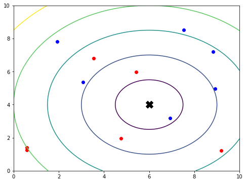

```python
np.random.seed(391)

X = np.random.uniform(0,10,24).reshape(12,2)
y = np.array(['red']*6 + ['blue']*6)

xticks = np.linspace(0, 10, 100)
yticks = np.linspace(0, 10, 100)
xgrid, ygrid = np.meshgrid(xticks, yticks)
Z = ((xgrid - 6)**2 + (ygrid - 4)**2)**0.5

plt.close()
plt.rcParams["figure.figsize"] = [8,6]
plt.scatter(X[:6,0],X[:6,1], c='r')
plt.scatter(X[6:,0],X[6:,1], c='b')
plt.scatter([6],[4], c='k', marker='X', s=200)
plt.contour(xgrid, ygrid, Z)
plt.show()
```

# Implementing the KNN Algorithm

We will provide an example sketching out how to implement the KNN classification algorithm. First, we will provide an example illustrating the `argsort` function, which will be useful in our implementation of the KNN algorithm.

### Preliminary: The argsort Function

```python
my_array = [7.8, 5.7, 4.8, 1.3, 6.4]
print(np.sort(my_array))
print(np.argsort(my_array))
```

```
[1.3 4.8 5.7 6.4 7.8]
[3 2 1 4 0]
```

We will now illustrate how to use base Python and numpy to perform KNN classification

```python
P = [6,4]

K = 5

#distances = []
#n = len(y)
#for i in range(n):
#    d = (P[0] - X[i,0])**2 + (P[1] - X[i,1])**2
#    distances.append(d)
# distances = np.array(distances)

distances = np.sum((X - P)**2, axis=1)

idx = np.argsort(distances)[:K]
knn_y = y[idx]
knn_d = distances[idx]

n_blue = np.sum(knn_y == 'blue')
n_red = np.sum(knn_y == 'red')

dist_blue = np.sum(knn_d[knn_y == 'blue'])
dist_red = np.sum(knn_d[knn_y == 'red'])

if n_red > n_blue:
    print('The predicted class for the point', P, 'is \'red\'.')
elif n_blue > n_red:
    print('The predicted class for the point', P, 'is \'blue\'.')
elif dist_red < dist_blue:
    print('The predicted class for the point', P, 'is \'red\'.')
else:
    print('The predicted class for the point', P, 'is \'blue\'.')
```

```
The predicted class for the point [6, 4] is 'blue'.
```

## KNN in Scikit Learn

We will now see several examples of using Scikit Learn to construct KNN classifiers.

```python
from sklearn.neighbors import KNeighborsClassifier
```

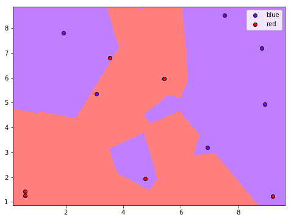

```python
# Experiment with different values of K and p

mod = KNeighborsClassifier(n_neighbors=3, p=2)
mod.fit(X,y)

plot_regions(mod, X, y, num_ticks=500)
```

## The Effect of Changing K

The example below explores how the choice of `K` affects the KNN algorithm. Notice that for small values of `K`, the decision boundary is jagged, conforms to the training data in very specific ways. When `K` is large, the decision boundary is smoother, and adapts more to the "global" structure of the training data than to local eccentricities. As a consequence, small values of `K` are more likely to result in over-fitting, while large values of `K` are more prone to producing models that underfit.

```python
import ipywidgets
df = pd.read_table('Data\knn_example.txt', sep='\t')
X = df.iloc[:,:2].values
y = df.iloc[:,2].values

def knn_example(K):
    mod = KNeighborsClassifier(K)
    mod.fit(X,y)
    plot_regions(mod, X, y)

slider = ipywidgets.IntSlider(min=1,max=400,step=1,value=1,continuous_update=False)
_ = ipywidgets.interact(knn_example, K=slider)
```

## Selecting Appropriate Value for K

As with all model hyperparameters, we use a validation set to select the value of `K` to be used in a KNN model.

```python
from sklearn.model_selection import train_test_split
```

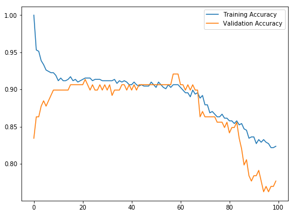

```
Maximum validation accuracy is equal to = 0.920863309352518
Maximum validation accuracy occurs at K = 57
```

```python
X_train, X_val, y_train, y_val = train_test_split(X, y, test_size = 0.2, random_state = 1)

train_acc = []
val_acc = []

for i in range(1,101):

    knn = KNeighborsClassifier(i)
    knn.fit(X_train, y_train)
    train_acc.append(knn.score(X_train, y_train))
    val_acc.append(knn.score(X_val, y_val))

plt.close()
plt.rcParams["figure.figsize"] = [8,6]
plt.plot(train_acc, label="Training Accuracy")
plt.plot(val_acc, label="Validation Accuracy")
plt.legend()
plt.show()
print('\n')
print('Maximum validation accuracy is equal to =', np.max(val_acc))
print('Maximum validation accuracy occurs at K =', np.argmax(val_acc))
```

## Comparison between KNN and Logistic Regression Classifiers

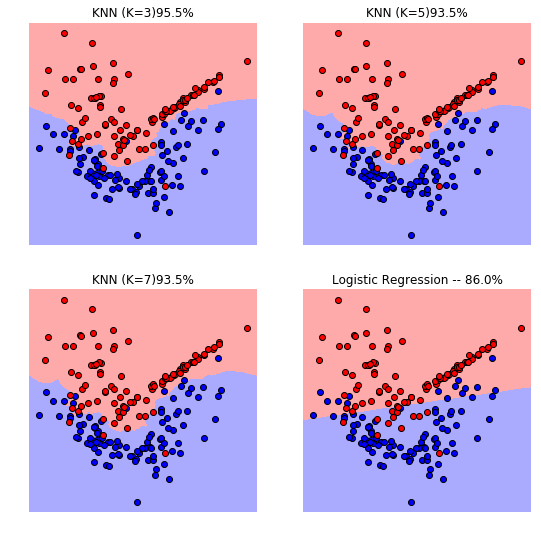

```python
np.random.seed(874)
%run -i snippets/snippet07.py
```

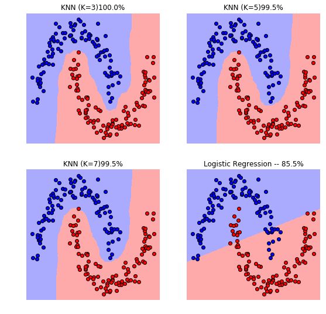

```python
%run -i snippets/snippet08.py
```

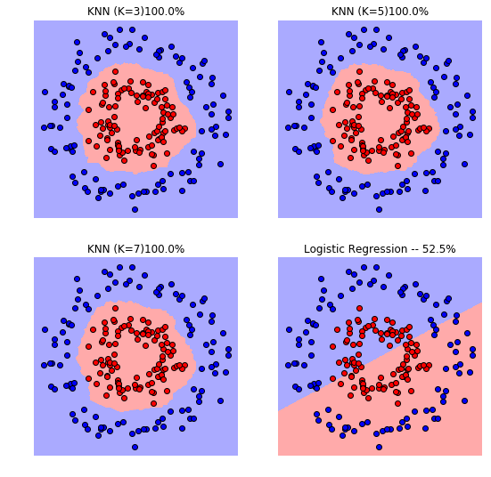

```python
%run -i snippets/snippet09.py
```

## Multiclass Classification with KNN

KNN can be easily addapted to multiclass classification problems.

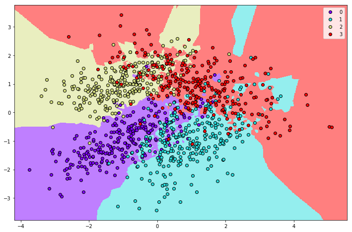

```python
np.random.seed(9)

X, y = skds.make_classification(n_samples = 1000, n_classes = 4,
                                n_features=2, n_redundant=0,
                                n_informative=2, n_clusters_per_class=1)

# Experiment with different values of K
knn = KNeighborsClassifier(3)
knn.fit(X, y)

plot_regions(knn, X, y, 500, fig_size=[12,8])
```

## Feature Scaling and KNN

It is generally necessary to scale (standardize / normalize) our features before applying a KNN algorithm. The importance of this is illustrated with the next example.

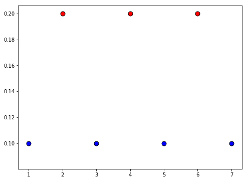

```python
x1 = np.array([1, 2, 3, 4, 5, 6, 7])
x2 = np.array([0.1, 0.2, 0.1, 0.2, 0.1, 0.2, 0.1])
X = np.hstack([x1.reshape(7,1), x2.reshape(7,1)])
y = np.array([0,1,0,1,0,1,0])

plt.close()
plt.rcParams["figure.figsize"] = [8,6]
plt.scatter(x1[y==0], x2[y==0], c='b', edgecolors='k', s=80)
plt.scatter(x1[y==1], x2[y==1], c='r', edgecolors='k', s=80)
plt.show()
```

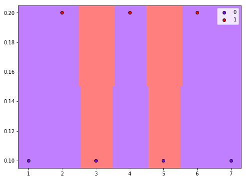

```python
knn = KNeighborsClassifier(3)
knn.fit(X,y)
plot_regions(knn, X, y)
```

```python
from sklearn.preprocessing import MinMaxScaler
```

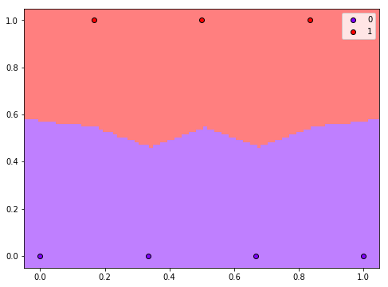

```python
scaler = MinMaxScaler()
Xs = scaler.fit_transform(X)

knn = KNeighborsClassifier(3)
knn.fit(Xs,y)
plot_regions(knn, Xs, y)
```

## Pros and Cons of KNN

**Pros**

- Easy to understand.
- Flexible (Although, one must be careful about overfitting.)
- No time required to train.
- Naturally adapts to multi-class classification.

**Cons**

- Making predictions is computationally intensive, and can be slow on a large dataset.
- Requires a meaningful notion of distance in the feature space.
- Generally requires features to be scaled/normalized.
- Model performance can be diminished when there are many dimensions. (Curse of dimensionality)

```python
def curse_of_dim(d):
    n_pairs = 10000
    P = np.random.uniform(0, 1, d*n_pairs).reshape(n_pairs, d)
    Q = np.random.uniform(0, 1, d*n_pairs).reshape(n_pairs, d)
    dist = np.sum((P - Q)**2, axis=1)**0.5 / np.sum(np.zeros(d) + 1)**0.5
    plt.figure(figsize=[8,6])
    plt.hist(dist, bins=20)
    plt.xlim([0,1])
    plt.show()

_ = ipywidgets.interact(curse_of_dim,
                     d=ipywidgets.IntSlider(min=1,max=1000,step=1,value=1,continuous_update=False))
```